# La correlación entre las inmigraciones y los índices de violencia en México

Inmigraciones vs Violencia

Ponce Sanchez, Max Albert  
Strater Mc Lellan, Luis Eduardo  
Puchuri Orellano, Piero Marcelo  
Cárdenas Aguirre, Sebastian Edgard  
Anticona Puza, Francescolli Gustavo(Líder de grupo)  
Profesor: Rojas Melasquez, Royer Edelwer

20/05/2020

# *Introducción*

Este estudio trata un tema sensible el cual es sobre la inmigración y la violencia. En este caso, se esta dando el enfoque en México donde se conoce que tiene una alta taza de violencia, sexismo y discriminación. Por lo que sería de interés saber si hay alguna relación entre estas dos variables.  
Con el paso de los años los países, en su mayoría países latinos, se han visto afectados por una gran cantidad de inmigrantes de diferentes partes del mundo por diversas razones. Este aumento progresivo de inmigraciones ha traído consigo beneficios y daños a la población donde se inmigra. Una de estos posibles daños es el aumento de crímenes/violencia tras la llegada de inmigrantes, sea por la misma población hacia los inmigrantes como los inmigrantes en si. Por ello, es que nos enfocamos en México pues, tienen una cultura muy diversa y un alto flujo de inmigrantes. Por lo que se busca ver una relación entre estos dos factores, el incremento violencia y las inmigraciones.

# **Objetivo**

Evaluar el crecimiento de violencia según las inmigraciones realizadas en México por medio de datos extraídos del Instituto Nacional de Estadística y Geografía(INEGI).

- **Objetivos Específicos**
  - Determinar cómo las inmigraciones en México pueden alterar el orden público.
  - Determinar que indicadores muestran una mayor relevancia.
  - Hallar una correlación entre el aumento de violencia y las inmigraciones.
  - Conocer la percerpción de los mexicanos sobre los extranjeros en su país.
  - Encontrar posibles relaciones que indiquen patronesde rechazo/intolerancia hacia los estranjeros en México.

# **Análisis Descriptivo**

- **Proporción de personas en México que piensan que generan inseguridad**
- **Intervalo de confianza**

```
## [1] 0.3579987
```

```
## [1] 0.3131198
```

- **Error**

```
## [1] 0.02243942
```

# **Cálculo de la prueba de Hipótesis**

Hipotesis: Al menos el 50% de los mexicanos se sienten inseguros frente a los extranjeros

#### Hipótesis con 50%

```
## [1] -11.38329
```

#### Hipótesis con 30%

```
## [1] 2.685787
```

#### Valor Crítico

```
## [1] -1.281552
```

#### Conclusión

- Dado que cae en la región de rechazo, rechazamos la hipótesis.

# **Análisis Descriptivo**

- **La proporción de personas que creen que los extrajeros quitan trabajo**
- **Intervalo de confianza**

```
## [1] 0.4743969
```

```
## [1] 0.4271056
```

- **Error**

```
## [1] 0.02364568
```

# **Cálculo de la prueba de Hipótesis**

Hipotesis: Al menos el 50% de los mexicanos sienten que los extranjeros quitan trabajos

#### Hipótesis con 50%

```
## [1] -3.409209
```

#### Hipótesis con 30%

```
## [1] 11.38622
```

#### Valor Crítico

```
## [1] -1.281552
```

#### Conclusión

- Dado que cae en la región de rechazo, rechazamos la hipótesis.

# **Cálculo de la Covarianza de Migraciones vs Percepción de Seguridad**

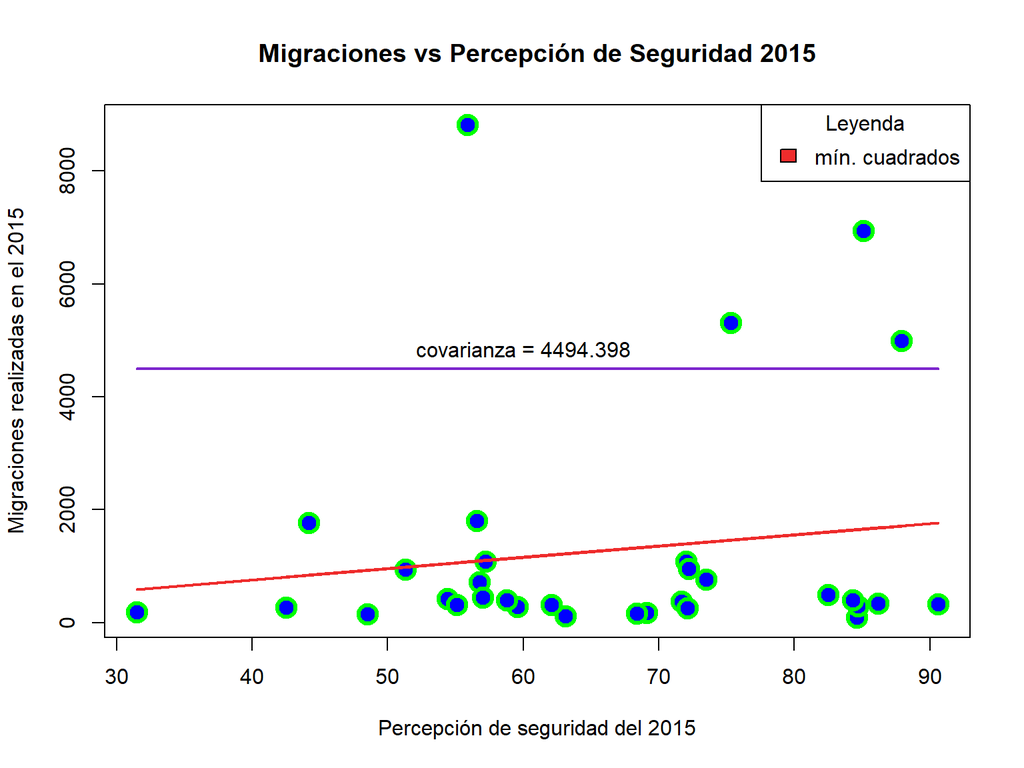

# **Cálculo de la Covarianza de Migraciones vs Percepción de Seguridad**

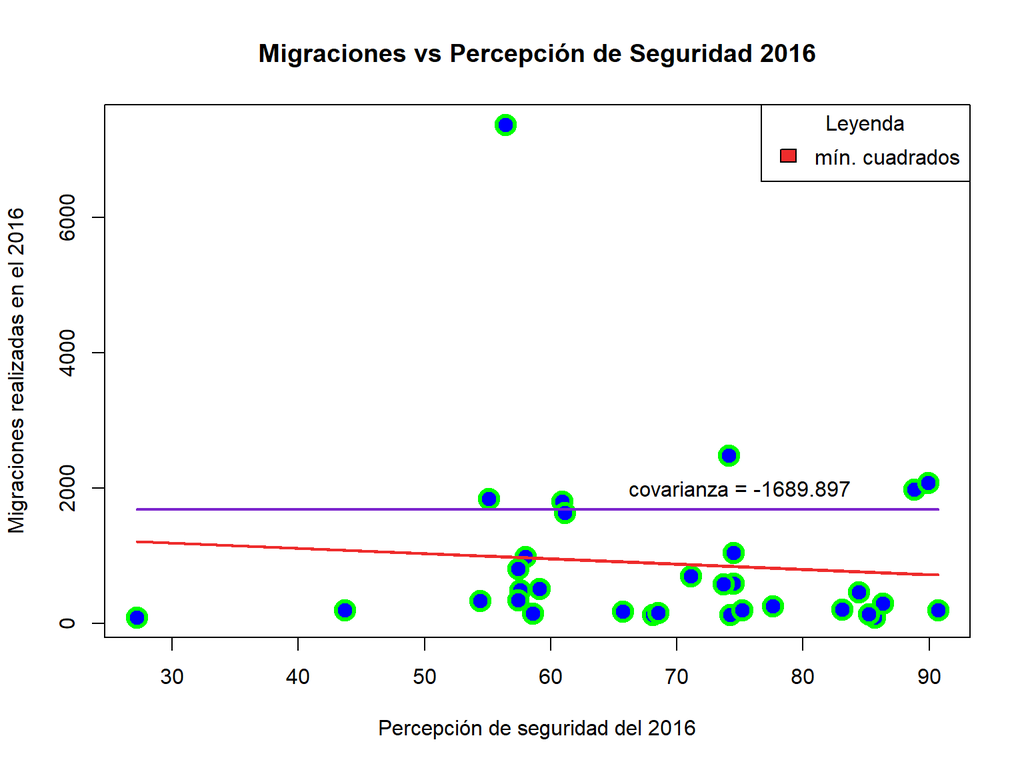

# **Cálculo de la Covarianza de Migraciones vs Percepción de Seguridad**

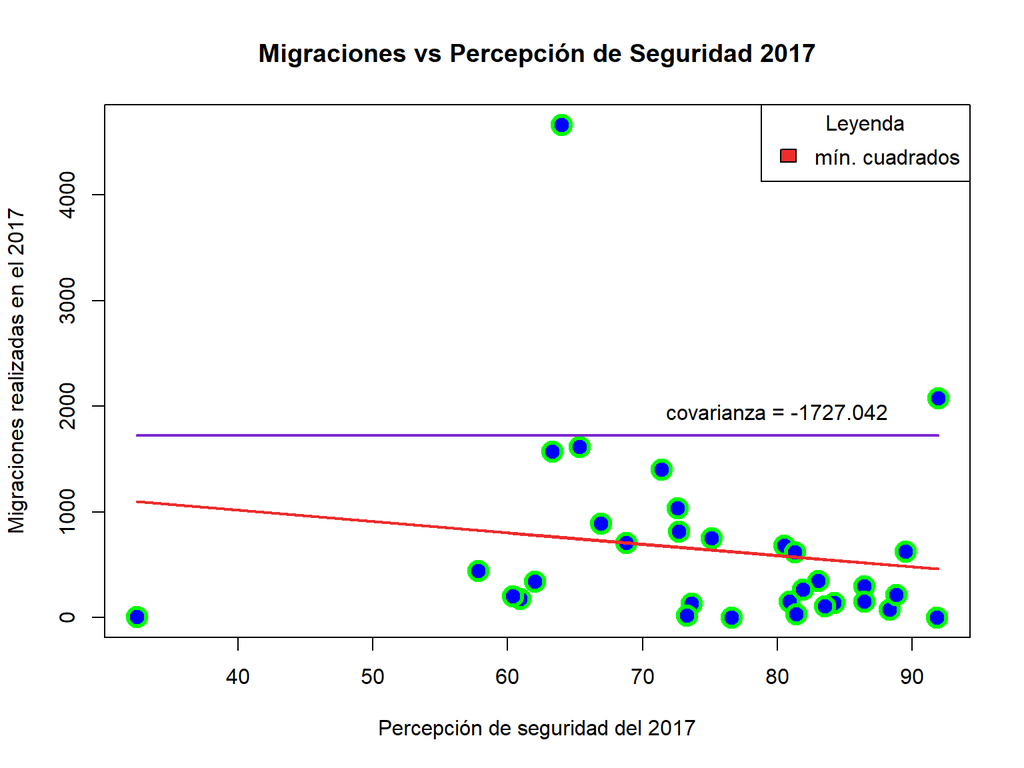

# **Cálculo de la Covarianza de Migraciones vs Percepción de Seguridad**

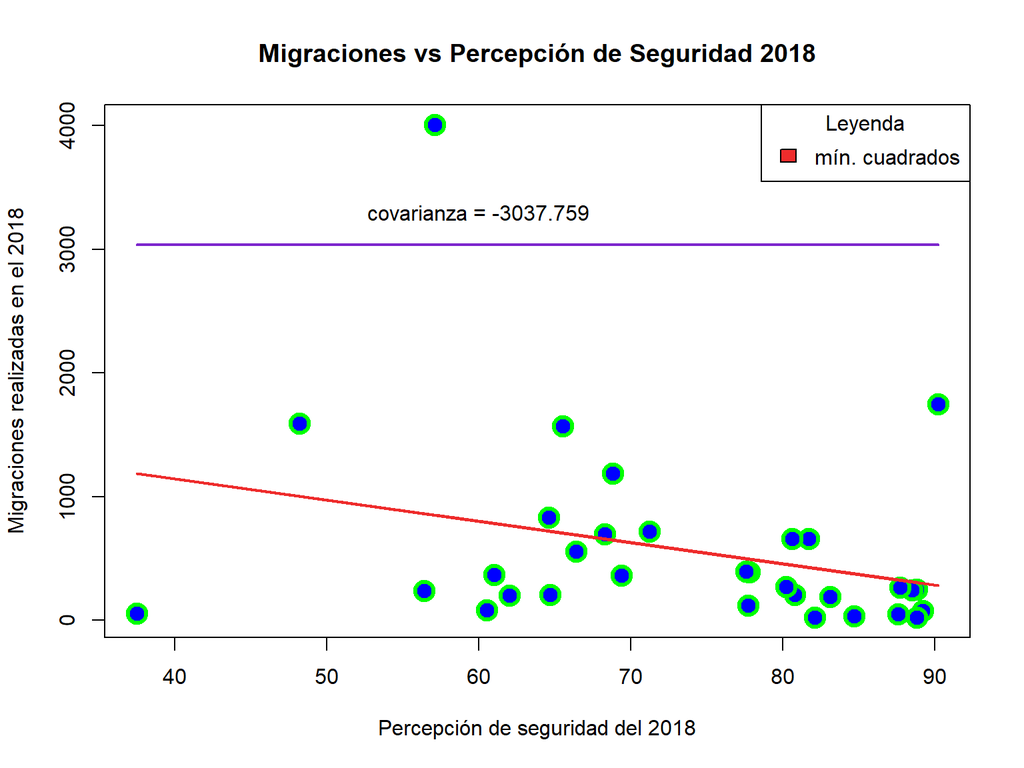